# Random Sampling & Law of Large Numbers

Applied Statistics

MTH-361A | Spring 2026 | University of Portland

# Objectives

- **Develop an understanding of the Law of Large Numbers**
- **Introduce the concept of the long-run average outcome**
- **Know how to simulate random sampling in R**

# Visualizing the Bernoulli PMF

The **Bernoulli PMF** can be visualized using the vertical line plot because the Bernoulli r.v. is discrete.

**Example:** Suppose that $p=0.60$, meaning the the “success” probability is $P(X=1)=0.60$ and the “failure” probability is $P(X=0)=0.40$.

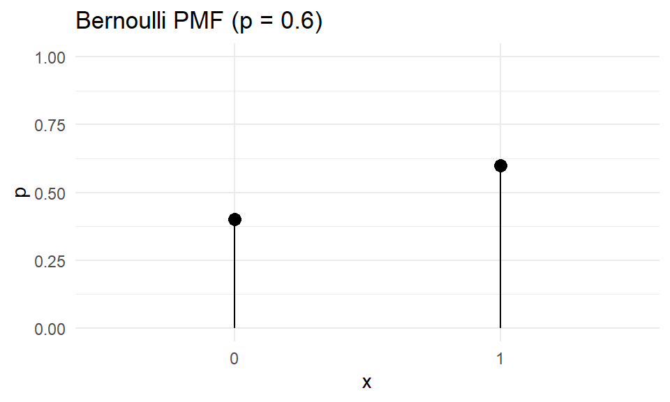

# Simulating Bernoulli Trials

A **Bernoulli trial** is a random experiment with two possible outcomes: success ($1$) or failure ($0$). The following R code uses the `tidyverse` package.

```r
# set hyperparameters
set.seed(42) # for reproducibility
n <- 10 # number of trials

# set parameter and PMF of the Bernoulli r.v
X <- c("1","0") # outcomes ("1"="success","0"="failure")
p <- 0.6 # probability of success
bern_pmf <- c(p,1-p) # an ordered list of outcome probabilities

# simulate n Bernoulli trials
samples <- sample(
  X, # set sample space
  size = n, # set number of samples
  prob = bern_pmf, # set probabilities for each outcome
  replace = TRUE # sampling with replacement
  )

# convert samples into tibble form and compute proportions
samples_tib <- tibble(X = samples) %>%
  # group by outcome
  group_by(X) %>%
  # summarisse by counting each outcome
  summarise(
    count = n(), # compute frequencies
    proportion= count/n # compute relative frequencies
    )

# view tibble
samples_tib
```

```
## # A tibble: 2 × 3
##   X     count proportion
##   <chr> <int>      <dbl>
## 1 0         7        0.7
## 2 1         3        0.3
```

# Visualizing the Simulated Bernoulli Trials

The Bernoulli trials simulations are considered nominal categorical data. A bar plot that shows the proportion of “success” and “failure” outcomes are most appropriate.

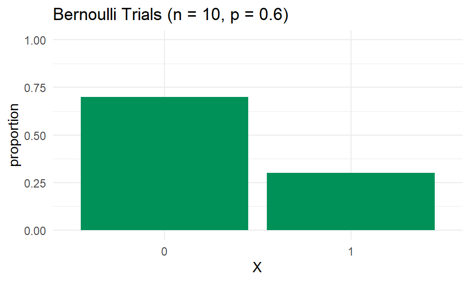

# Comparing the Bernoulli PMF vs the Trials

We can compare the Bernoulli PMF and the Trials by plotting the plots side-by-side for easy comparison.

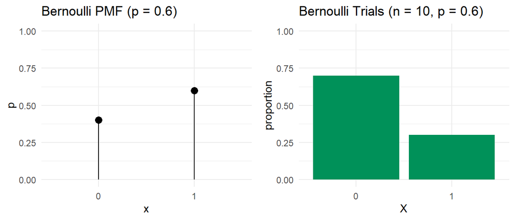

$\star$ Since we only have $10$ trials the proportions of the samples is not quite the same as the parameters of the Bernoulli r.v. due to **sampling variability**.

# Increasing the Number of Bernoulli Trials

Suppose we increase the number of Bernoulli Trials and compare it to the Bernoulli PMF.

Let $p = 0.60$ (“success” probability) and $n = 1000$ (number of Bernoulli Trials).

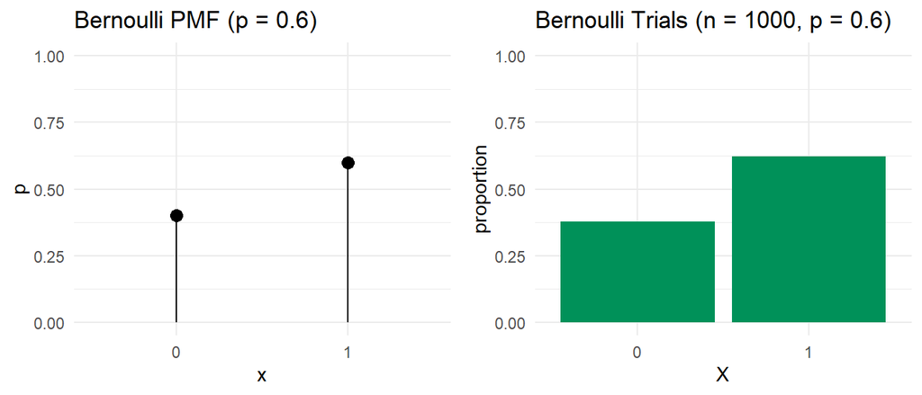

$\star$ As we increase the number of Bernoulli trials from $n = 10$ to $n = 1000$, the proportion of $1$ and $0$ are close to the Bernoulli PMF, which shows the **frequentist interpretation of Probability**.

# The Law of Large Numbers

The **Law of Large Numbers** states that as the number of trials in a random experiment increases, the sample mean approaches the expected value.

**Example Bernoulli Trials Simulation**

Let $p = 0.60$ be the “success” probability of a Bernoulli r.v., $X \sim \text{Bern}(0.60)$, where $\text{E}(X) = 0.60$.

$\star$ By the Law of Large Numbers, as the number of Bernoulli trials increases, the sample proportion of “success” converges to the expected value.